# Vessel Segmentation Dataset

## The purpose of this notebook is to:

1. Display the dataset which will be utilized in the AHA project
2. Display the input to stage 2 of our model
3. Demonstrate some of the key augmentation methods to prevent overfitting

## About dataset

- 119 images
- 512 x 512 grayscale images (original input)
- Stage 2 input: 512 x 512 x 3 channels (original input, stage 1 segmentation map, edge map of stage 1 segmentation map)

### Imports

```python
import numpy as np
from data_loader import *
from utils import augment_imageset
import matplotlib.pyplot as plt
%matplotlib inline
%load_ext autoreload
%autoreload 2
```

### Load data

```python
stage_1_data, stage_1_filenames = load_train_test_images(cv=0, stage=1)

#
#   Unpack Images from data; all in (n x c x h x w) format
#
stage_1_train_x_imgs = stage_1_data["train_x_images"]
stage_1_train_y_imgs = stage_1_data["train_y_images"]
stage_1_test_x_imgs = stage_1_data["test_x_images"]
stage_1_test_y_imgs = stage_1_data["test_y_images"]
stage_1_train_filenames  = stage_1_filenames["train_filenames"]
stage_1_test_filenames = stage_1_filenames["test_filenames"]
```

### Check shape (should be 119 images total for each x and y dataset)

```python
print("stage_1_train_x_imgs shape: %s" % str(stage_1_train_x_imgs.shape))
print("stage_1_train_y_imgs shape: %s" % str(stage_1_train_y_imgs.shape))
print("stage_1_test_x_imgs shape: %s" % str(stage_1_test_x_imgs.shape))
print("stage_1_test_y_imgs shape: %s" % str(stage_1_test_y_imgs.shape))
```

```
stage_1_train_x_imgs shape: (96, 1, 512, 512)
stage_1_train_y_imgs shape: (96, 1, 512, 512)
stage_1_test_x_imgs shape: (23, 1, 512, 512)
stage_1_test_y_imgs shape: (23, 1, 512, 512)
```

### Note default split is 80% / 20% for 5-fold Cross Validation; this is a configurable parameter

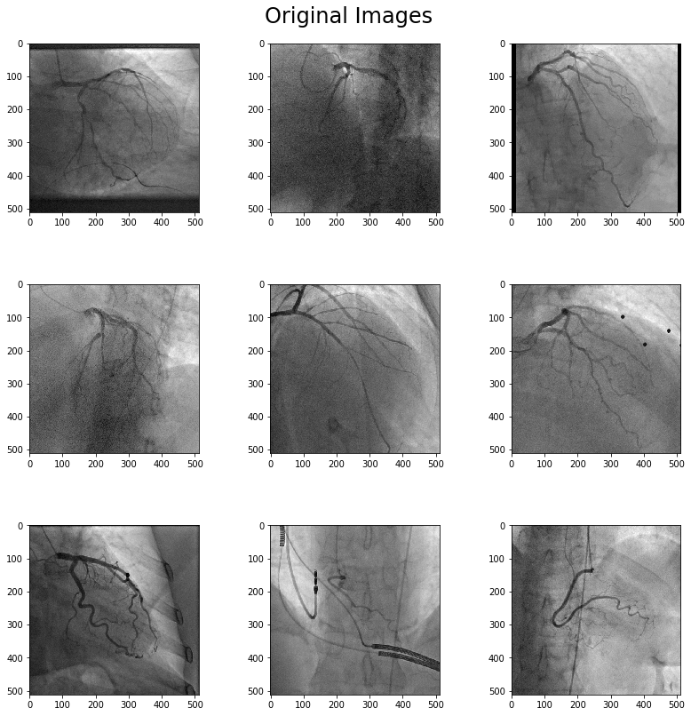

```python
fig, axs = plt.subplots(3,3,figsize=(12,12))
fig.suptitle("Original Images", fontsize=24);
fig.tight_layout(pad=5)

# Loop 1-9 for image subplots
for row in range(3):
    for col in range(3):
        axs[row, col].imshow(np.squeeze(stage_1_train_x_imgs[(row * 3 + col)]), cmap='gray')
```

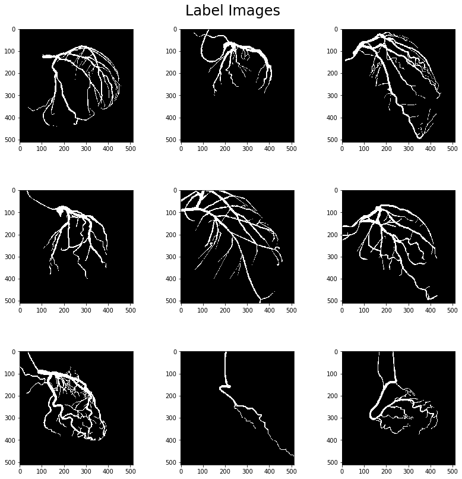

```python
fig, axs = plt.subplots(3,3,figsize=(12,12))
fig.suptitle("Label Images", fontsize=24);
fig.tight_layout(pad=5)

# Loop 1-9 for image subplots
for row in range(3):
    for col in range(3):
        axs[row, col].imshow(np.squeeze(stage_1_train_y_imgs[(row * 3 + col)]), cmap='gray')
```

# Test some of the transformations

#### Note: augment_imageset performs the following transformations (each can be individually set):

- Horizontal and Vertical flips (one or the other)
- Rotations
- Translations
- Top and bottom hat transforms (one or the other)
- Random Gaussian and Salt & Pepper Noise (one or the other) #### Uses skimage, skimage.morphology, and cv2

```python
img_x = stage_1_train_x_imgs[-1]
img_y = stage_1_train_y_imgs[-1]
```

### Display images

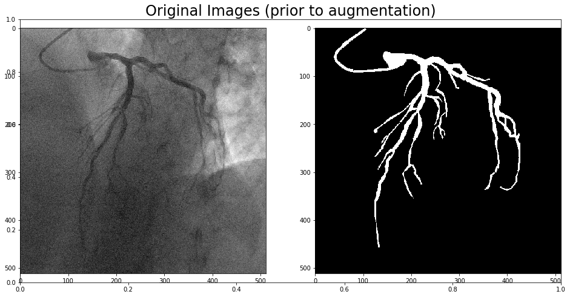

```python
fig = plt.figure(figsize=(16,8))
plt.title("Original Images (prior to augmentation)", fontsize=24);
fig.add_subplot(121)
plt.imshow(np.squeeze(img_x), cmap='gray')
fig.add_subplot(122)
plt.imshow(np.squeeze(img_y), cmap='gray')
```

### Augment images

```python
# quick function to display augmented images with 20% chance of of being augmented for a given augmentation
def display_augmentations(img_x, img_y):
    new_x, new_y = augment_imageset(img_x, img_y, probability_threshold=0.2, flip=True, rotate=True,
                                translate=True, tophat=True, noise=True)
    fig = plt.figure(figsize=(16,8))
    fig.add_subplot(121)
    plt.imshow(np.squeeze(new_x), cmap='gray')
    fig.add_subplot(122)
    plt.imshow(np.squeeze(new_y), cmap='gray')
```

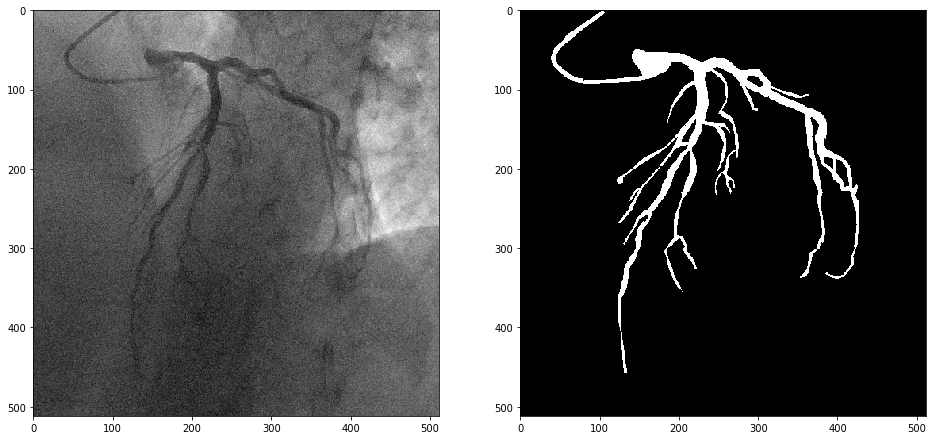

```python
display_augmentations(img_x, img_y)
```

- The top-hat filter, or white top-hat is used to enhance bright objects in a darker background.

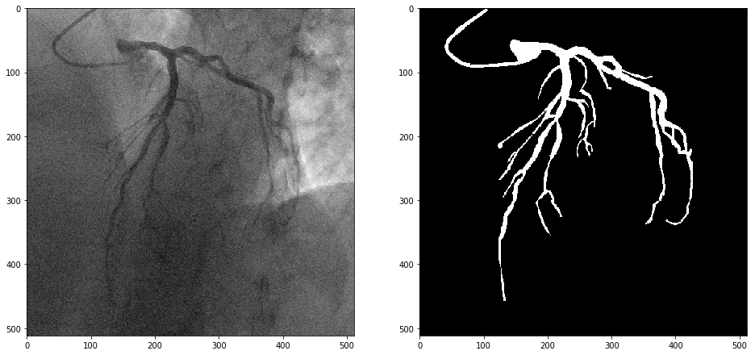

```python
display_augmentations(img_x, img_y)
```

```python
stage_2_data, stage_2_filenames = load_train_test_images(cv=2, stage=2)

#
#   Unpack Images from data; all in (n x c x h x w) format
#
stage_2_train_x_imgs = stage_2_data["train_x_images"]
stage_2_train_y_imgs = stage_2_data["train_y_images"]
stage_2_test_x_imgs = stage_2_data["test_x_images"]
stage_2_test_y_imgs = stage_2_data["test_y_images"]
stage_2_train_filenames  = stage_2_filenames["train_filenames"]
stage_2_test_filenames = stage_2_filenames["test_filenames"]
```

```python
print("stage_2_train_x_imgs shape: %s" % str(stage_2_train_x_imgs.shape))
print("stage_2_train_y_imgs shape: %s" % str(stage_2_train_y_imgs.shape))
print("stage_2_test_x_imgs shape: %s" % str(stage_2_test_x_imgs.shape))
print("stage_2_test_y_imgs shape: %s" % str(stage_2_test_y_imgs.shape))
```

```
stage_2_train_x_imgs shape: (96, 3, 512, 512)
stage_2_train_y_imgs shape: (96, 1, 512, 512)
stage_2_test_x_imgs shape: (23, 3, 512, 512)
stage_2_test_y_imgs shape: (23, 1, 512, 512)
```

### 119 total images. Note three channels to dataset x

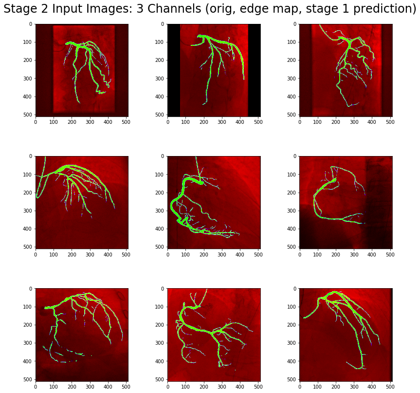

```python
fig, axs = plt.subplots(3,3,figsize=(12,12))
fig.suptitle("Stage 2 Input Images: 3 Channels (orig, edge map, stage 1 prediction)", fontsize=24);
fig.tight_layout(pad=5)

# Loop 1-9 for image subplots
for row in range(3):
    for col in range(3):
        axs[row, col].imshow(np.squeeze(np.transpose(stage_2_train_x_imgs[(row * 3 + col)], axes=(1,2,0))))
```

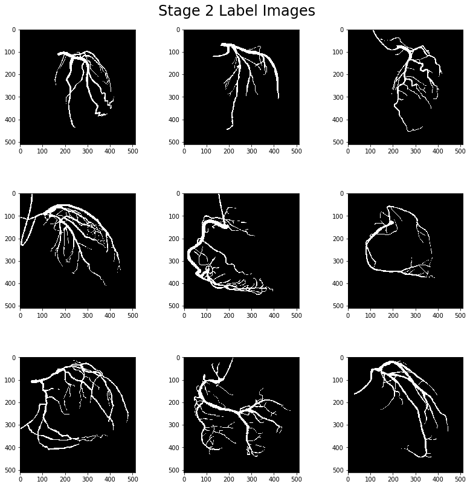

```python
fig, axs = plt.subplots(3,3,figsize=(12,12))
fig.suptitle("Stage 2 Label Images", fontsize=24);
fig.tight_layout(pad=5)

# Loop 1-9 for image subplots
for row in range(3):
    for col in range(3):
        axs[row, col].imshow(np.squeeze(stage_2_train_y_imgs[(row * 3 + col)]), cmap='gray')
```

### Augment images

```python
# quick function to display augmented images with 20% chance of of being augmented for a given augmentation
def stage_2_augmentations(img_x, img_y):
    new_x, new_y = augment_imageset(img_x, img_y, probability_threshold=0.2, flip=True, rotate=True,
                                translate=True, tophat=True, noise=True)
    fig = plt.figure(figsize=(16,8))
    fig.add_subplot(121)
    plt.imshow(np.transpose(new_x, axes=(1,2,0)))
    fig.add_subplot(122)
    plt.imshow(np.squeeze(new_y))
```

### Get our stage 2 images ready:

```python
img_x_2 = stage_2_train_x_imgs[-51]
img_y_2 = stage_2_train_y_imgs[-51]
```

### Originals:

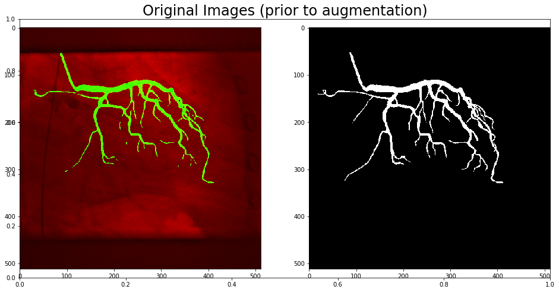

```python
fig = plt.figure(figsize=(16,8))
plt.title("Original Images (prior to augmentation)", fontsize=24);
fig.add_subplot(121)
plt.imshow(np.transpose(img_x_2, axes=(1,2,0)))
fig.add_subplot(122)
plt.imshow(np.squeeze(img_y_2), cmap='gray')
```

### Augmentation

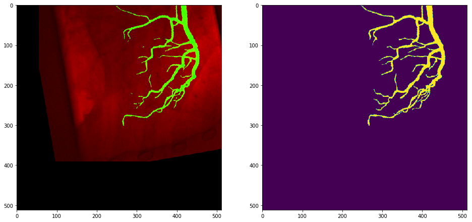

```python
stage_2_augmentations(img_x_2, img_y_2)
```

### You can clearly see we have rotation and flipping. Let's try another

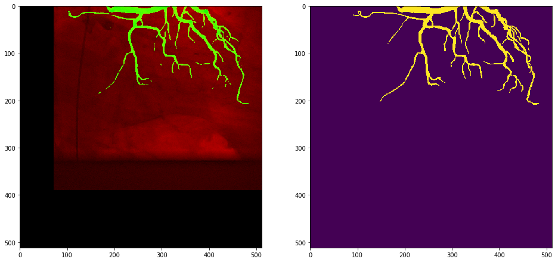

```python
stage_2_augmentations(img_x_2, img_y_2)
```

- The black top-hat filter, or bottom-hat filter enhances dark objects in the background.